# 4.5 Ordinal regression

Author

Affiliation

Vladimir Buskin

Catholic University of Eichstätt-Ingolstadt

Abstract

Modelling categorical (ordinal) response variables.

## Suggested reading

General:

> Baguley (2012): Chapter 17.4.5

> O’Connell (2006)

> Powers and Xie (2008): Chapter 7

> [Documentation of Cumulative Link Models](https://cran.r-project.org/web/packages/ordinal/vignettes/clm_article.pdf)

## Introduction

In her recent contribution, Glass (2021) examines possible reasons why certain transitive verbs have a stronger affinity towards object omission compared to others, placing special emphasis on the routinisation of the actions denoted by the verbs. Specifically, she assesses **how high/low-routine contexts affect the acceptability of object omission** for transitive verbs from different frequency bins.

We will replicate her findings using her survey data `Glass_2021_survey_processed.csv`[^1]:

<sup>1</sup> The original dataset can be retrieved from Lelia Glass’s OSF repository: https://osf.io/t6zw5 [Last accessed: 27th September, 2024].

```r
# Load libraries
library(tidyverse)
library(ordinal)
library(MASS)
library(sjPlot)
library(effects)
library(ggeffects)
library(ggpubr)

# For additional tests
library(DescTools)
library(generalhoslem)
library(brant)

# Load data
survey <- read.csv("../datasets/Glass_2021_survey_processed.csv")

# Inspect dataset
str(survey)
```

```
'data.frame':   784 obs. of  5 variables:
 $ rating       : int  3 4 3 3 2 4 3 2 3 2 ...
 $ freq         : chr  "hi" "lo" "lo" "hi" ...
 $ verb         : chr  "pick" "catch" "throw" "break" ...
 $ ParticipantID: chr  "Participant1" "Participant1" "Participant1" "Participant1" ...
 $ routine      : chr  "hi" "lo" "lo" "lo" ...
```

```r
head(survey)
```

```
  rating freq   verb ParticipantID routine
1      3   hi   pick  Participant1      hi
2      4   lo  catch  Participant1      lo
3      3   lo  throw  Participant1      lo
4      3   hi  break  Participant1      lo
5      2   hi  taste  Participant1      hi
6      4   hi bottle  Participant1      hi
```

**Short breakdown of the variables**

- `routine`: In Glass’s study, transitive verbs were randomly assigned to one of the following conditions:
> - (High routine condition:) I worked at my poultry farm. Just like I always do, I **butchered** some chickens. Then I gathered some eggs.
> - (Low-routine condition:) I visited a friend’s job. Just because people wanted me to try it, I **butchered** some chickens. Then I went for a walk.

> Cf. Glass (2021: 66)

```r
unique(survey$routine)
```

```
[1] "hi" "lo"
```

- `rating` records the responses of participants to a follow-up question regarding the acceptability of object omission. The answers are recorded on a 1-5 Likert scale.

> *The next time Caroline talks about butchering chickens the day before, how likely do you think she is to say the following?*

> ‘I **butchered** yesterday’

> Cf. Glass (2021: 66)

```r
unique(survey$rating)
```

```
[1] 3 4 2 5 1
```

- `verb` contains the items to be rated for the conditions in `routine`

```r
unique(survey$verb)
```

```
[1] "pick"   "catch"  "throw"  "break"  "taste"  "bottle" "sell"   "chop"
```

- `frequency` relates to the frequency bins of the verbs:

```r
unique(survey$freq)
```

```
[1] "hi" "lo"
```

- `ParticipantID` identifies each of the 98 subjects who provided ratings

## Descriptive overview

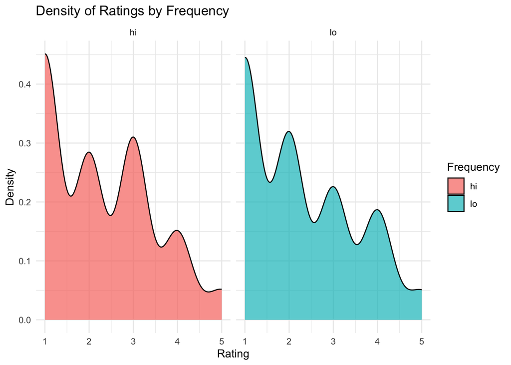

```r
ggplot(survey, aes(x = rating, fill = freq)) +
  geom_density(alpha = 0.7) +
  facet_wrap(~freq) +
  theme_minimal() +
  labs(title = "Density of Ratings by Frequency",
       x = "Rating", y = "Density", fill = "Frequency")
```

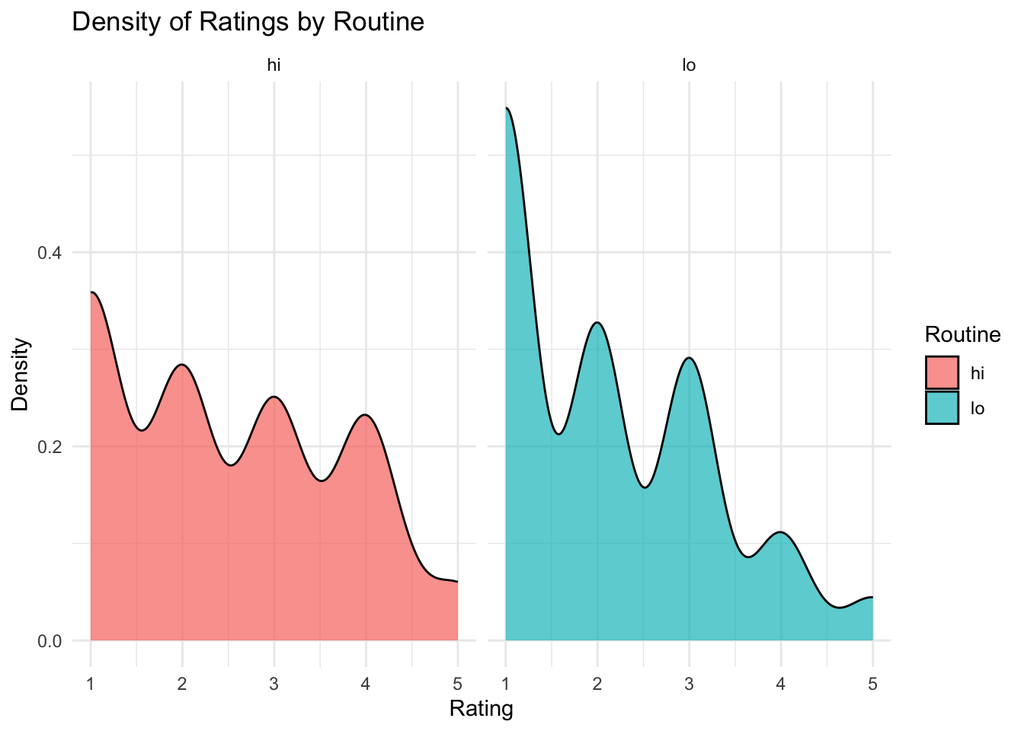

```r
ggplot(survey, aes(x = rating, fill = routine)) +
  geom_density(alpha = 0.7) +
  facet_wrap(~routine) +
  theme_minimal() +
  labs(title = "Density of Ratings by Routine",
       x = "Rating", y = "Density", fill = "Routine")
```

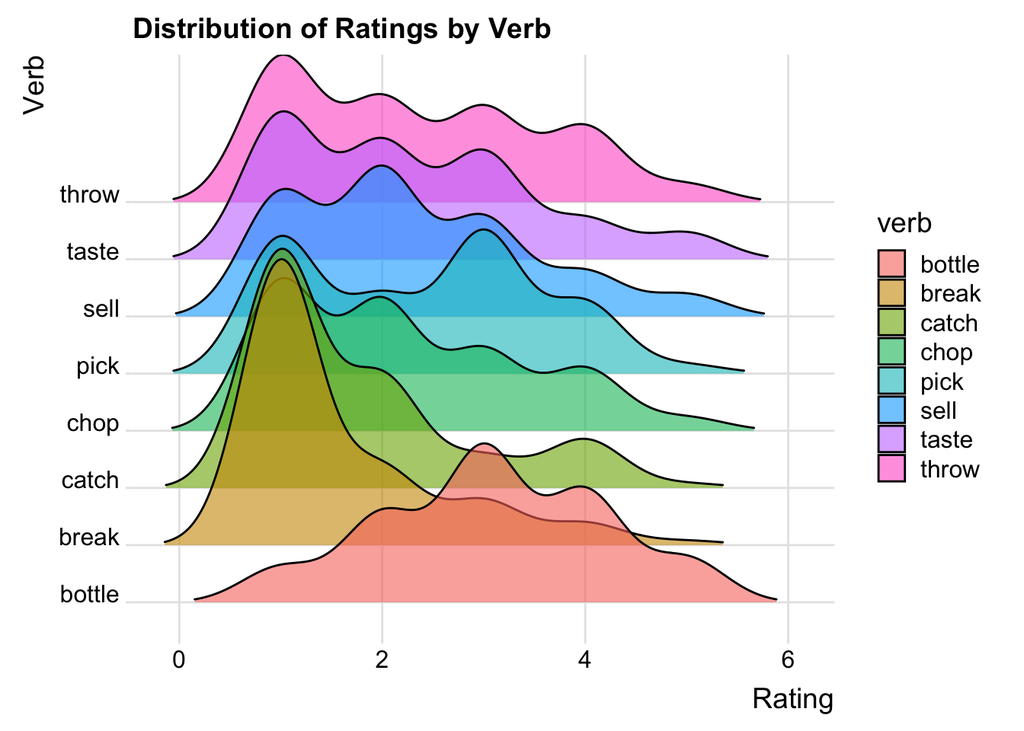

```r
library(ggridges)
ggplot(survey, aes(x = rating, y = verb, fill = verb)) +
  geom_density_ridges(scale = 5, rel_min_height = 0.01, alpha = 0.6) +
  theme_ridges() +
  #theme(legend.position = "none") +
  labs(title = "Distribution of Ratings by Verb",
       x = "Rating", y = "Verb")
```

## Modelling ordinal data

Our task is clear: We need to measure how `routine` and `freq` affect the variability in the acceptability ratings, while controlling for repeated measurements for `verb` and `ParticipantID`, which impose a hierarchical structure on the dataset.

Formally speaking, we have $p$ explanatory variables $X_1, X_2, ..., X_p$ for $1, ..., p$. The target variable, i.e. our $Y$, is `rating` with the ordered, discrete outcomes $y \in \{1, 2, 3, 4, 5\}$.

The goal is to find a model $f$ that describes the relationship between $Y$ and $X_p$ as accurately as possible and minimises the error term $\epsilon$:

$$Y = f(X_1, X_2, ..., X_p) + \epsilon
\tag{1}$$

### Ordered logistic regression

One family of models that respects the ordered, yet categorical nature of $Y$ is **ordered** (or ordinal) **logistic regression**. Other terms include **proportional odds models** and **cumulative logit/link models**.

**Recap: Logistic regression**

Logistic regression is used to model categorical response variables with two or more levels. For instance, let’s assume our $Y$ is dichotomous with the following two outcomes:

$$Y =
\begin{cases}
\text{yes} \\
\text{no}
\end{cases}
\tag{2}$$

Using the logistic function, we can estimate the probability of one outcome versus the other **given** the predictors $X_p$. Their log-transformed odds ratio (**log odds**) is equivalent of the all-too-familiar linear model:

$$\log\left(\frac{P(Y = yes \mid X_1, X_2, ..., X_p)}{1 - P(Y = yes \mid X_1, X_2, ..., X_p)}\right) = \beta_0 + \sum_{i=1}^p \beta_iX_i
\tag{3}$$

Core to this approach is the notion of **cumulative probabilities**. Let $J$ denote the number of ordered categories in $Y$. In Glass’s case study, the estimated cumulative probabilities for each ordered outcome (= acceptability rating) would have the forms in Equation 4.

$$\begin{array}{rcl}
P(Y \leq 1) & = & P(Y = 1) \\
P(Y \leq 2) & = & P(Y = 1) + P(Y = 2) \\
P(Y \leq 3) & = & P(Y = 1) + P(Y = 2) + P(Y = 3) \\
& \vdots & \\
P(Y \leq j) & = & P_1 + ... + P_j
\end{array}
\tag{4}$$

We can now update our logistic regression model to take into account cumulative probabilities for $j = 1, ..., J-1$.

$$\log\left(\frac{P(Y \leq j \mid X_1, X_2, ..., X_p)}{1 - P(Y \leq j \mid X_1, X_2, ..., X_p)}\right) = \beta_0 + \sum_{i=1}^p \beta_iX_i
\tag{5}$$

The intercepts $\beta_{0_j}$ serve as **cutpoints** between the adjacent ordinal categories. For $J = 5$ categories, there are $J - 1 = 4$ cutpoints, i.e.,

- 1|2 for $P(Y \leq 1)$
- 2|3 for $P(Y \leq 2)$
- 3|4 for $P(Y \leq 3)$
- 4|5 for $P(Y \leq 4)$.

Given a change in predictor values, the slope coefficients $\beta_pX_p$ indicate how the probability of being in a higher rating category changes (Baguley 2012: 691–2).

We can obtain “regular” probabilities from the cumulative ones by drawing on the equivalence in Equation 6.

$$P(Y = j) = P(Y \leq j) - P(Y \leq j - 1)
\tag{6}$$

For instance, the probability $P(Y = 3)$ is equivalent to

$$P(Y = 3) = P(Y \leq 3) - P(Y \leq 2).
\tag{7}$$

**Assumptions of proportional odds models**

**The proportional odds assumption** stipulates a stable effect of the predictors on the (log) odds of the ordinal outcomes across all possible cutpoints (O’Connell 2006: 29). In case of violation, it is better to rely on partial proportional odds models or multinomial logistic regression instead.

## Application in R

There are several R packages that support ordinal logistic regression models. This section provides an overview of some of the more common (as well as well-documented) implementations.

### Using `polr()` from the `MASS` library

```r
# Convert to factor and determine ordering
survey$rating <- factor(survey$rating, ordered = TRUE, levels = c("1", "2", "3", "4", "5"))

# Fit polr model
survey.polr <- polr(rating ~
                      freq +
                      routine,
                      data = survey)

# Model summary
summary(survey.polr)
```

```
Re-fitting to get Hessian
```

```
Call:
polr(formula = rating ~ freq + routine, data = survey)

Coefficients:
             Value Std. Error  t value
freqlo    -0.01095     0.1291 -0.08483
routinelo -0.55521     0.1302 -4.26449

Intercepts:
    Value   Std. Error t value
1|2 -0.8704  0.1228    -7.0859
2|3  0.1342  0.1188     1.1290
3|4  1.2528  0.1293     9.6856
4|5  2.8915  0.2003    14.4345

Residual Deviance: 2246.662
AIC: 2258.662
```

```r
# R-squared and AIC
PseudoR2(survey.polr, c("Nagelkerke", "AIC"))
```

```
  Nagelkerke          AIC
   0.0244793 2258.6617419
```

```r
tab_model(survey.polr, show.se = TRUE, show.aic = TRUE, show.dev = TRUE, transform = NULL)
```

```
Re-fitting to get Hessian
```

|  | rating |  |  |  |
| --- | --- | --- | --- | --- |
| Predictors | Log-Odds | std. Error | CI | p |
| 1\|2 | -0.87 | 0.12 | -1.11 – -0.63 | **<0.001** |
| 2\|3 | 0.13 | 0.12 | -0.10 – 0.37 | 0.259 |
| 3\|4 | 1.25 | 0.13 | 1.00 – 1.51 | **<0.001** |
| 4\|5 | 2.89 | 0.20 | 2.50 – 3.28 | **<0.001** |
| freq [lo] | -0.01 | 0.13 | -0.26 – 0.24 | 0.932 |
| routine [lo] | -0.56 | 0.13 | -0.81 – -0.30 | **<0.001** |
| Observations | 784 |  |  |  |
| R<sup>2</sup> Nagelkerke | 0.024 |  |  |  |
| Deviance | 2246.662 |  |  |  |
| AIC | 2258.662 |  |  |  |

**Interpreting the model parameters**

### Testing assumptions and goodness of fit

- Test proportional odds assumption:

```r
brant(survey.polr) # p < 0.05 is a violation of the assumption
```

```
--------------------------------------------
Test for    X2  df  probability
--------------------------------------------
Omnibus     14.45   6   0.02
freqlo      6.5 3   0.09
routinelo   8.14    3   0.04
--------------------------------------------

H0: Parallel Regression Assumption holds
```

- Hosmer-Lemeshow test, which is essentially a $\chi^2$-test:

```r
logitgof(survey$rating, # observed
         fitted(survey.polr), # expected
         ord = TRUE) # respect ordering
```

```
    Hosmer and Lemeshow test (ordinal model)

data:  survey$rating, fitted(survey.polr)
X-squared = 51.173, df = 35, p-value = 0.03808
```

- The Lipsitz test is an extension of the Hosmer-Lemeshow test. Note that it requires the response to be a factor.

```r
lipsitz.test(survey.polr)
```

```
    Lipsitz goodness of fit test for ordinal response models

data:  formula:  rating ~ freq + routine
LR statistic = 20.261, df = 9, p-value = 0.01637
```

- Part of the same family of tests is the Pulkstenis-Robinson test, which also relies on the $\chi^2$-distribution:

```r
pulkrob.chisq(survey.polr, catvars = c("freq", "routine"))
```

```
    Pulkstenis-Robinson chi-squared test

data:  formula:  rating ~ freq + routine
X-squared = 21.476, df = 9, p-value = 0.0107
```

### Visualisation

#### With `effects`

```r
# Routine effect plot
plot(Effect(focal.predictors = c("routine"), mod = survey.polr), rug = FALSE, style="stacked")
```

[output not shown]

#### With `ggeffects` and `ggplot2`

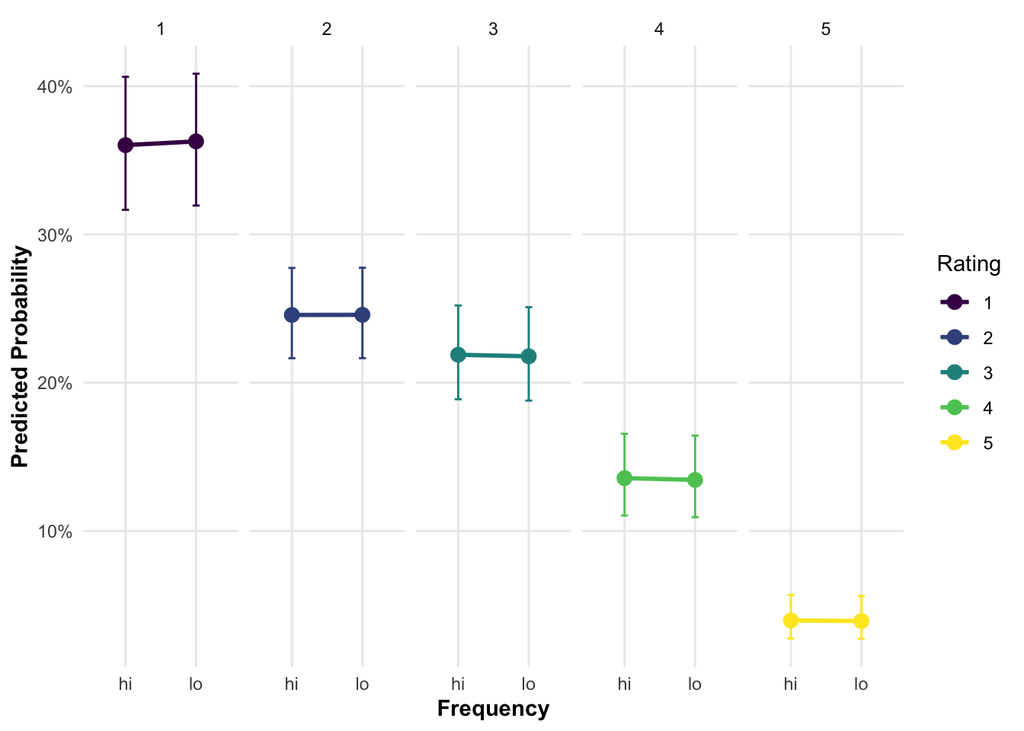

```r
# Get the ggeffects data
eff <- ggeffects::ggeffect(survey.polr, "freq")

# Convert to a data frame
plot_data <- as.data.frame(eff)

# Ensure the response.level has the desired levels
plot_data$response.level <- factor(plot_data$response.level,
                                   levels = c("X1", "X2", "X3", "X4", "X5"),
                                   labels = c("1", "2", "3", "4", "5"))

# Create the plot with confidence intervals
p1 <- ggplot(plot_data, aes(x = x, y = predicted, color = response.level, group = response.level)) +
  geom_line(linewidth = 1) +
  geom_point(size = 3) +
  geom_errorbar(aes(ymin = conf.low, ymax = conf.high), width = 0.1, linewidth = 0.5) +
  scale_color_viridis_d() +
  labs(
    x = "Frequency",
    y = "Predicted Probability",
    color = "Rating"
  ) +
  facet_grid(~ response.level) +
  theme_minimal() +
  theme(
    legend.position = "right",
    panel.grid.minor = element_blank(),
    axis.title = element_text(face = "bold"),
    plot.title = element_text(face = "bold"),
    plot.subtitle = element_text(margin = margin(b = 10))
  ) +
  scale_y_continuous(labels = scales::percent_format(accuracy = 1))

p1
```

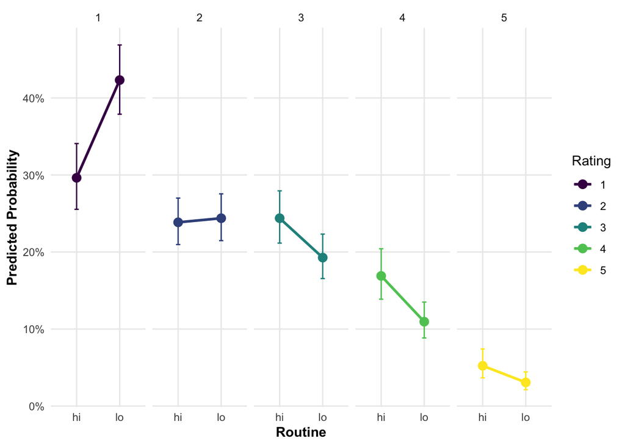

```r
# Get the ggeffects data for "routine"
eff_routine <- ggeffects::ggeffect(survey.polr, "routine")

# Convert to a data frame
plot_data_routine <- as.data.frame(eff_routine)

# Ensure the response.level has the desired levels for "routine"
plot_data_routine$response.level <- factor(plot_data_routine$response.level,
                                           levels = c("X1", "X2", "X3", "X4", "X5"),
                                           labels = c("1", "2", "3", "4", "5"))

# Create the second plot for "routine"
p2 <- ggplot(plot_data_routine, aes(x = x, y = predicted, color = response.level, group = response.level)) +
  geom_line(linewidth = 1) +
  geom_point(size = 3) +
  geom_errorbar(aes(ymin = conf.low, ymax = conf.high), width = 0.1, linewidth = 0.5) +
  scale_color_viridis_d() +
  labs(
    x = "Routine",
    y = "Predicted Probability",
    color = "Rating"
  ) +
  facet_grid(~ response.level) +
  theme_minimal() +
  theme(
    legend.position = "right",
    panel.grid.minor = element_blank(),
    axis.title = element_text(face = "bold"),
    plot.title = element_text(face = "bold"),
    plot.subtitle = element_text(margin = margin(b = 10))
  ) +
  scale_y_continuous(labels = scales::percent_format(accuracy = 1))

p2
```

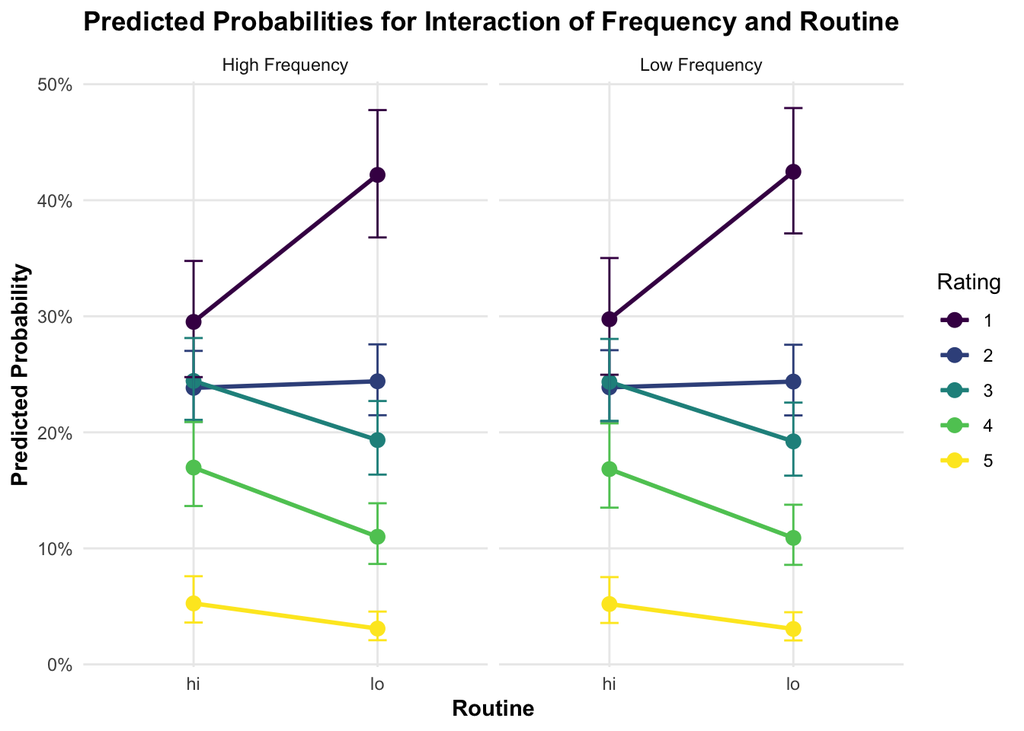

```r
# Generate the interaction effects for "freq" and "routine"
eff_interaction <- ggeffect(survey.polr, terms = c("freq", "routine"))

# Convert to a data frame
plot_data_interaction <- as.data.frame(eff_interaction)

# Ensure the response.level has the desired levels
plot_data_interaction$response.level <- factor(plot_data_interaction$response.level,
                                               levels = c("X1", "X2", "X3", "X4", "X5"),
                                               labels = c("1", "2", "3", "4", "5"))


# Create the interaction plot with facet by 'x' and color by 'response.level'
p_interaction <- ggplot(plot_data_interaction, aes(x = group, y = predicted, color = response.level, group = response.level)) +
  geom_line(linewidth = 1) +
  geom_point(size = 3) +
  geom_errorbar(aes(ymin = conf.low, ymax = conf.high), width = 0.1, linewidth = 0.5) +
  scale_color_viridis_d() +
  labs(
    title = "Predicted Probabilities for Interaction of Frequency and Routine",
    x = "Routine",
    y = "Predicted Probability",
    color = "Rating"
  ) +
  facet_wrap(~ x, labeller = labeller(x = c("hi" = "High Frequency", "lo" = "Low Frequency"))) +  # Facet by "freq"
  theme_minimal() +
  theme(
    legend.position = "right",
    panel.grid.minor = element_blank(),
    axis.title = element_text(face = "bold"),
    plot.title = element_text(face = "bold"),
    plot.subtitle = element_text(margin = margin(b = 10))
  ) +
  scale_y_continuous(labels = scales::percent_format(accuracy = 1))

# Display the interaction plot
p_interaction
```

### Using `clm()` from the `ordinal` library

```r
# Convert to factor and determine ordering
survey$rating <- factor(survey$rating, ordered = TRUE, levels = c("1", "2", "3", "4", "5"))

# Fit cumulative link model
clm.1 <- ordinal::clm(rating ~
                    freq +
                    routine,
                    data = survey, Hess=TRUE)

# Model summary
summary(clm.1)
```

[output not shown]

```r
tab_model(clm.1, show.se = TRUE, show.aic = TRUE, show.dev = TRUE, transform = NULL)
```

|  | rating |  |  |  |
| --- | --- | --- | --- | --- |
| Predictors | Log-Odds | std. Error | CI | p |
| 1\|2 | -0.87 | 0.12 | -1.11 – -0.63 | **<0.001** |
| 2\|3 | 0.13 | 0.12 | -0.10 – 0.37 | 0.259 |
| 3\|4 | 1.25 | 0.13 | 1.00 – 1.51 | **<0.001** |
| 4\|5 | 2.89 | 0.20 | 2.50 – 3.28 | **<0.001** |
| freq [lo] | -0.01 | 0.13 | -0.26 – 0.24 | 0.932 |
| routine [lo] | -0.56 | 0.13 | -0.81 – -0.30 | **<0.001** |
| Observations | 784 |  |  |  |
| R<sup>2</sup> Nagelkerke | 0.024 |  |  |  |
| AIC | 2258.662 |  |  |  |

### Mixed-effects ordinal regression

**Recap: Mixed-effects models**

If the data is nested according to some grouping factor with $1, ..., k$ groups, we can let the intercept and/or slopes vary by group. For instance, recall the varying-intercept model:

$$Y = \alpha_{k} + \beta_1X_{1} + \beta_2X_{2} + ... + \epsilon \qquad \alpha_{k} \sim N(\mu_{\alpha}, \sigma_{\alpha}^2).$$
In this case we also speak of **random effects**.

```r
# Convert to factor and determine ordering
survey$rating <- factor(survey$rating, ordered = TRUE, levels = c("1", "2", "3", "4", "5"))

# Fit mixed model with random intercepts for "verb" and "ParticipantID"
clm.2 <- ordinal::clmm(rating ~
                    freq * routine +
                    (1 | verb) +
                    (1 | ParticipantID),
                    data = survey, Hess=TRUE)

# Model summary
summary(clm.2)
```

```
Cumulative Link Mixed Model fitted with the Laplace approximation

formula: rating ~ freq * routine + (1 | verb) + (1 | ParticipantID)
data:    survey

 link  threshold nobs logLik  AIC     niter     max.grad cond.H
 logit flexible  784  -991.65 2001.30 598(2386) 3.81e-04 1.5e+02

Random effects:
 Groups        Name        Variance Std.Dev.
 ParticipantID (Intercept) 2.0628   1.4363
 verb          (Intercept) 0.9059   0.9518
Number of groups:  ParticipantID 98,  verb 8

Coefficients:
                 Estimate Std. Error z value Pr(>|z|)
freqlo            -0.1567     0.2138  -0.733 0.463437
routinelo         -0.7473     0.2103  -3.553 0.000381 ***
freqlo:routinelo  -0.1406     0.2981  -0.472 0.637046
---
Signif. codes:  0 '***' 0.001 '**' 0.01 '*' 0.05 '.' 0.1 ' ' 1

Threshold coefficients:
    Estimate Std. Error z value
1|2  -1.3562     0.4020  -3.374
2|3   0.2062     0.3988   0.517
3|4   1.8329     0.4053   4.523
4|5   3.8639     0.4401   8.780
```

```r
tab_model(clm.2, show.se = TRUE, show.aic = TRUE, show.dev = TRUE, transform = NULL)
```

|  | rating |  |  |  |
| --- | --- | --- | --- | --- |
| Predictors | Log-Odds | std. Error | CI | p |
| 1\|2 | -1.36 | 0.40 | -2.14 – -0.57 | **0.001** |
| 2\|3 | 0.21 | 0.40 | -0.58 – 0.99 | 0.605 |
| 3\|4 | 1.83 | 0.41 | 1.04 – 2.63 | **<0.001** |
| 4\|5 | 3.86 | 0.44 | 3.00 – 4.73 | **<0.001** |
| freq [lo] | -0.16 | 0.21 | -0.58 – 0.26 | 0.463 |
| routine [lo] | -0.75 | 0.21 | -1.16 – -0.34 | **<0.001** |
| freq [lo] × routine [lo] | -0.14 | 0.30 | -0.72 – 0.44 | 0.637 |
| Random Effects |  |  |  |  |
| σ<sup>2</sup> | 3.29 |  |  |  |
| τ<sub>00</sub> <sub>ParticipantID</sub> | 2.06 |  |  |  |
| τ<sub>00</sub> <sub>verb</sub> | 0.91 |  |  |  |
| ICC | 0.47 |  |  |  |
| N <sub>verb</sub> | 8 |  |  |  |
| N <sub>ParticipantID</sub> | 98 |  |  |  |
| Observations | 784 |  |  |  |
| Marginal R<sup>2</sup> / Conditional R<sup>2</sup> | 0.028 / 0.489 |  |  |  |
| AIC | 2001.305 |  |  |  |

```r
# Extract random effects
re_verb <- ranef(clm.2)$verb
re_participant <- ranef(clm.2)$ParticipantID

# Create dataframes for random effects
df_verb <- data.frame(verb = rownames(re_verb), re = re_verb[,1])
df_participant <- data.frame(ParticipantID = rownames(re_participant), re = re_participant[,1])

# Get predictions for an average case
pred_avg <- ggpredict(clm.2, terms = c("freq", "routine"))
```

[output not shown]

[output not shown]

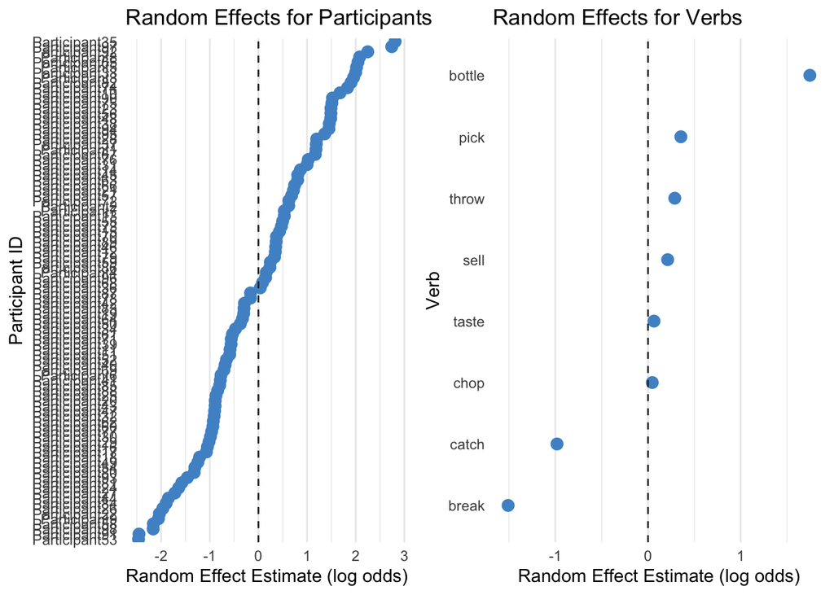

```r
# Add random effects to predictions
pred_verb <- crossing(pred_avg, df_verb) %>%
  mutate(predicted = predicted + re)

pred_participant <- crossing(pred_avg, df_participant) %>%
  mutate(predicted = predicted + re)

# Create a horizontal dot plot for random effects of participants
p_caterpillar <- ggplot(df_participant, aes(x = re, y = reorder(ParticipantID, re))) +
  geom_point(size = 3, color = "steelblue3") +  # Dots representing the random effects
  labs(title = "Random Effects for Participants",
       x = "Random Effect Estimate (log odds)",
       y = "Participant ID") +
   geom_vline(xintercept = 0, linetype = "dashed", color = "grey20") +
  theme_minimal() +
  theme(panel.grid.major.y = element_blank())  # Removes the gridlines for y-axis

p_caterpillar2 <- ggplot(df_verb, aes(x = re, y = reorder(verb, re))) +
  geom_point(size = 3, color = "steelblue3") +  # Dots representing the random effects
  labs(title = "Random Effects for Verbs",
       x = "Random Effect Estimate (log odds)",
       y = "Verb") +
   geom_vline(xintercept = 0, linetype = "dashed", color = "grey20") +
  theme_minimal() +
  theme(panel.grid.major.y = element_blank())  # Removes the gridlines for y-axis

ggarrange(p_caterpillar, p_caterpillar2, ncol = 2, common.legend = TRUE, legend = "right")
```

## Generalised Additive Mixed-effects Models (GAMMs)

### Suggested reading

For linguists:

> Baayen & Linke (2020)

General:

> Hastie & Tibshirani (1991)

> Wood (2006)

### Rationale

A core assumption of Generalised Linear Models (GLMs) is a linear relationship between predictor(s) and response. If, however, one is interested in exploring potential non-linear trends without the risk of extreme overfitting, GAMs offer an elegant solution: Instead of relying on the linear sum of model coefficients, GAMs estimate more flexible **smooth terms** $f_k$ for $k = 1, ..., p$. For illustration, Equation 8 shows a linear additive model for a continuous target variable with $p$ predictors.

$$Y = \beta_0 + \sum\limits_{k = 1}^p f_k(X_k)
\tag{8}$$

### Application in R

```r
# Load libraries
library(mgcv)
library(itsadug)
library(gratia)

# Convert predictors to factors
survey$ParticipantID <- as.factor(survey$ParticipantID)
survey$verb <- as.factor(survey$verb)

# Fit GAMM
gam1 <- bam(as.numeric(rating) ~ # treated as numeric term
              freq + # linear term
              routine + # linear term
              s(ParticipantID, bs = "re") + # smooth term
              s(verb, bs = "re"), # smooth term
              data = survey,
              family = ocat(R = 5) # number of ordinal categories
            )

# Model summary
summary(gam1)
```

```
Family: Ordered Categorical(-1,0.51,2.09,4.06)
Link function: identity

Formula:
as.numeric(rating) ~ freq + routine + s(ParticipantID, bs = "re") +
    s(verb, bs = "re")

Parametric coefficients:
            Estimate Std. Error t value Pr(>|t|)
(Intercept)   0.3613     0.3880   0.931    0.352
freqlo       -0.2195     0.1431  -1.534    0.125
routinelo    -0.7752     0.1428  -5.430 7.79e-08 ***
---
Signif. codes:  0 '***' 0.001 '**' 0.01 '*' 0.05 '.' 0.1 ' ' 1

Approximate significance of smooth terms:
                    edf Ref.df      F p-value
s(ParticipantID) 77.654     97  4.677  <2e-16 ***
s(verb)           6.728      7 25.860  <2e-16 ***
---
Signif. codes:  0 '***' 0.001 '**' 0.01 '*' 0.05 '.' 0.1 ' ' 1

Deviance explained = 27.3%
fREML =   1631  Scale est. = 1         n = 784
```

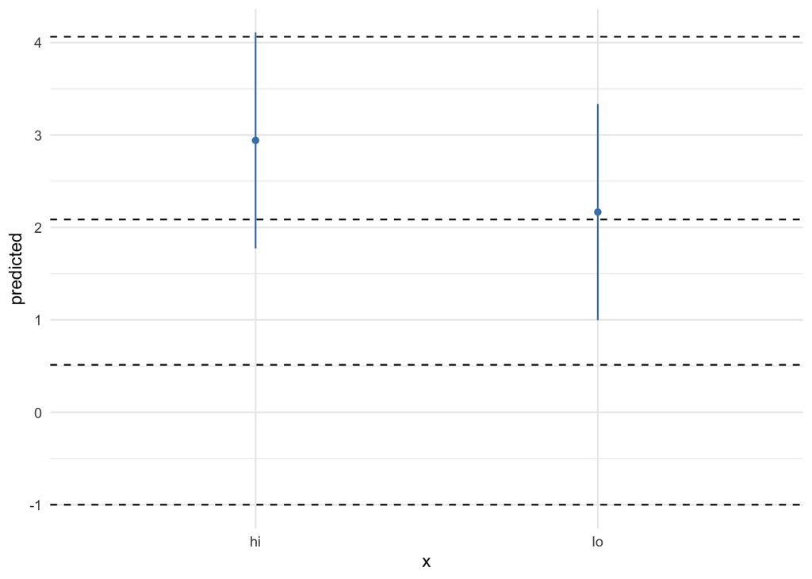

```r
# Extract the intercepts for plotting
thresh <- gratia::theta(gam1) %>%
  tibble::as_tibble() %>%
  setNames(c("threshold"))

# Extract predictions for "routine"
routine_pred <- ggpredict(gam1, terms = "routine")

# Plot predictions
routine_pred %>%
  ggplot(aes(x = x, y = predicted)) +
  geom_point(col = "steelblue") +
  geom_errorbar(aes(ymin = conf.low, ymax = conf.high, width = 0), col = "steelblue") +
  geom_hline(data = thresh, aes(yintercept = threshold), linetype = "dashed") +
  theme_minimal()
```

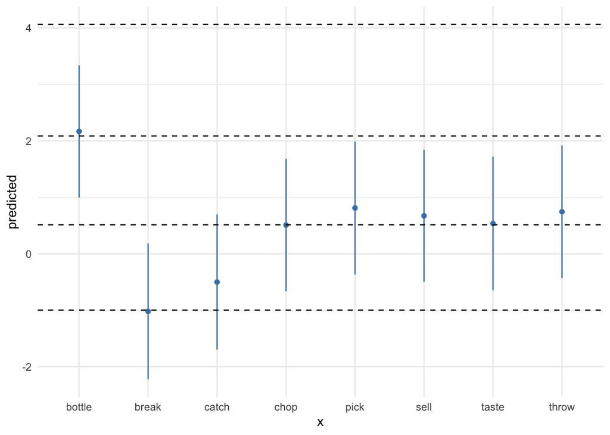

```r
# Extract random effects for "verb"
verb_pred <- ggpredict(gam1, terms = "verb")

# Plot random effect
verb_pred %>%
  ggplot(aes(x = x, y = predicted)) +
  geom_point(col = "steelblue") +
  geom_errorbar(aes(ymin = conf.low, ymax = conf.high, width = 0), col = "steelblue") +
  geom_hline(data = thresh, aes(yintercept = threshold), linetype = "dashed") +
  theme_minimal()
```

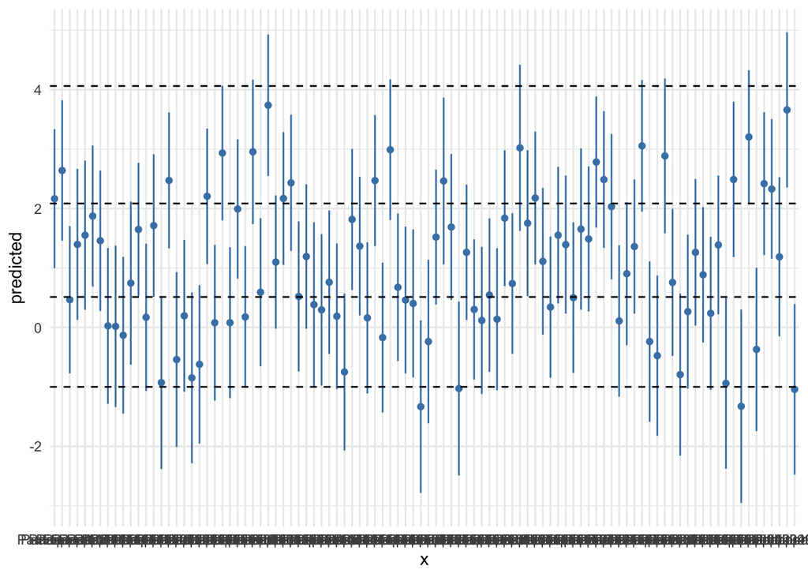

```r
# Extract random effects for "ParticipantID"
subj_pred <- ggpredict(gam1, terms = "ParticipantID")

# Plot random effect
subj_pred |>
  ggplot(aes(x = x, y = predicted)) +
  geom_point(col = "steelblue") +
  geom_errorbar(aes(ymin = conf.low, ymax = conf.high, width = 0), col = "steelblue") +
  #geom_line() +
  geom_hline(data = thresh, aes(yintercept = threshold), linetype = "dashed") +
  theme_minimal()
```

## References

Baayen, R. Harald, and Maja Linke. 2020. “Generalized Additive Mixed Models.” In *A Practical Handbook of Corpus Linguistics*, edited by Magali Paquot and Stefan Thomas Gries, 563–91. Cham: Springer.

Baguley, Thomas. 2012. *Serious Stats: A Guide to Advanced Statistics for the Behavioral Sciences*. Houndmills, Basingstoke: Palgrave Macmillan.

Glass, Lelia. 2021. “English Verbs Can Omit Their Objects When They Describe Routines.” *English Language and Linguistics* 26 (1): 49–73. https://doi.org/10.1017/S1360674321000022.

Hastie, Trevor, and Robert Tibshirani. 1991. *Generalized Additive Models*. London: Chapman & Hall.

O’Connell, Ann A. 2006. *Logistic Regression Models for Ordinal Response Variables*. Vol. 146. Thousand Oaks, Calif.: Sage.

Powers, Daniel A., and Yu Xie. 2008. *Statistical Methods for Categorical Data Analysis*. 2. ed. Bingley: Emerald.

Wood, Simon N. 2006. *Generalized Additive Models: An Introduction with R*. Boca Raton: Chapman & Hall/CRC.